# Sweep Demo

Matt Dancho

September 19, 2017

# sweep: What’s It Used For?

Tidying the `forecast` package workflow. Like `broom` is to `stats` library, `sweep` is to `forecast` package.

# Load Libraries

```r
# devtools::install_github("business-science/sweep")
# devtools::install_github("business-science/timetk")
# devtools::install_github("business-science/tidyquant")
# install.packages("forecast")
library(sweep)      # Broom-style tidiers for the forecast package
library(timetk)     # Functions working with time series
library(tidyquant)  # Loads tidyverse, financial pkgs, used to get data
library(forecast)   # Forecasting models and predictions package
```

# Data

Get data using `tidyquant`. The data comes from FRED: [Panama Canal Traffic](https://fred.stlouisfed.org/series/S4248SM144NCEN).

```r
# Beer, Wine, Distilled Alcoholic Beverages, in Millions USD
panama_canal_tbl <- tq_get("M03028USM576NNBR", get = "economic.data", from = "1920-01-01", to = "1949-12-31")

panama_canal_tbl
```

```
## # A tibble: 360 x 2
##          date price
##        <date> <int>
##  1 1920-01-01   895
##  2 1920-02-01   780
##  3 1920-03-01   894
##  4 1920-04-01   867
##  5 1920-05-01   975
##  6 1920-06-01   834
##  7 1920-07-01   886
##  8 1920-08-01  1040
##  9 1920-09-01  1009
## 10 1920-10-01   991
## # ... with 350 more rows
```

Visualize the data… nothing new here.

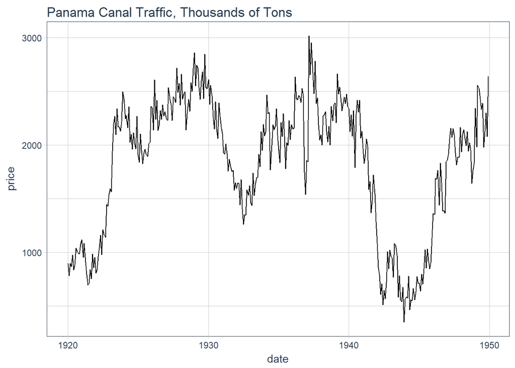

```r
# Plot Panama Canal Traffic
panama_canal_tbl %>%
    ggplot(aes(date, price)) +
    geom_line() +
    theme_tq() +
    labs(title = "Panama Canal Traffic, Thousands of Tons")
```

# Forecasting using Forecast and Sweep

**Key Insight**:

Forecasting using the `forecast` package is a non-tidy process that involves `ts` class objects. We have seen this system before where we can “tidy” these objects. For the `stats` library, we have `broom`, which tidies models and predictions. For the `forecast` package we now have `sweep`, which tidies models and forecasts.

**Objective**: We’ll work through an ARIMA analysis to forecast the next 24 months of time series data.

### Step 1: Create ts object

Use `timetk::tk_ts()` to convert from `tbl` to `ts`.

```r
# Convert from tbl to ts
panama_canal_ts <- tk_ts(panama_canal_tbl, start = 1920, freq = 12)

panama_canal_ts
```

```
##       Jan  Feb  Mar  Apr  May  Jun  Jul  Aug  Sep  Oct  Nov  Dec
## 1920  895  780  894  867  975  834  886 1040 1009  991  985 1077
## 1921 1117  953 1084  908  793  695  709  839  754  985  855  952
## 1922  807  838  960 1046 1158  977 1211 1166 1138 1446 1427 1535
## 1923 1592 1563 1941 2187 2265 2096 2338 2168 2168 2127 2218 2495
## 1924 2427 2244 2272 2159 2354 2023 2097 1958 2112 2018 1962 2266
## 1925 1907 1839 2104 1951 1823 1920 1960 1912 1891 2009 2023 2358
## 1926 2346 2139 2606 2237 2416 2133 2185 2320 2238 2374 2271 2308
## 1927 2240 2229 2533 2429 2378 2228 2449 2429 2396 2716 2488 2572
## 1928 2371 2659 2427 2473 2496 2139 2291 2424 2312 2581 2500 2713
## 1929 2858 2549 2742 2718 2536 2423 2597 2680 2431 2844 2533 2523
## 1930 2611 2377 2557 2456 2261 2147 2401 2147 2058 2393 2262 2165
## 1931 2106 1929 1914 2009 1924 1757 1865 1788 1753 1763 1577 1649
## 1932 1594 1645 1643 1442 1676 1404 1259 1348 1345 1581 1531 1620
## 1933 1462 1434 1737 1526 1628 1690 1698 1913 1795 2124 1949 2191
```

[output cut: 16 more lines]

### Step 2A: Model using ARIMA

We can use the `auto.arima()` function from the `forecast` package to model.

```r
# Model using auto.arima
fit_arima <- auto.arima(panama_canal_ts)

fit_arima
```

```
## Series: panama_canal_ts
## ARIMA(1,1,0)(2,0,0)[12]
##
## Coefficients:
##           ar1    sar1    sar2
##       -0.3589  0.2441  0.1817
## s.e.   0.0498  0.0533  0.0536
##
## sigma^2 estimated as 31973:  log likelihood=-2370.82
## AIC=4749.63   AICc=4749.74   BIC=4765.16
```

### Step 2B: Tidy the Model

Like `broom` tidies the `stats` package, we can use `sweep` functions to tidy the ARIMA model.

```r
# sw_tidy - Get model coefficients
sw_tidy(fit_arima)
```

```
## # A tibble: 3 x 2
##    term   estimate
##   <chr>      <dbl>
## 1   ar1 -0.3588992
## 2  sar1  0.2440575
## 3  sar2  0.1816895
```

```r
# sw_glance - Get model and accuracy measures
sw_glance(fit_arima)
```

```
## # A tibble: 1 x 12
##                model.desc    sigma    logLik      AIC      BIC      ME
##                     <chr>    <dbl>     <dbl>    <dbl>    <dbl>   <dbl>
## 1 ARIMA(1,1,0)(2,0,0)[12] 178.8109 -2370.815 4749.631 4765.164 4.26714
## # ... with 6 more variables: RMSE <dbl>, MAE <dbl>, MPE <dbl>, MAPE <dbl>,
## #   MASE <dbl>, ACF1 <dbl>
```

```r
# sw_augment - get model residuals
sw_augment(fit_arima, timetk_idx = TRUE)
```

```
## # A tibble: 360 x 4
##         index .actual   .fitted       .resid
##        <date>   <dbl>     <dbl>        <dbl>
##  1 1920-01-01     895  894.1050    0.8949994
##  2 1920-02-01     780  880.7475 -100.7474921
##  3 1920-03-01     894  825.7390   68.2610157
##  4 1920-04-01     867  853.9388   13.0611840
##  5 1920-05-01     975  882.7290   92.2709901
##  6 1920-06-01     834  929.9540  -95.9539683
##  7 1920-07-01     886  884.7120    1.2880459
##  8 1920-08-01    1040  877.8783  162.1216732
##  9 1920-09-01    1009  986.3868   22.6132055
## 10 1920-10-01     991 1017.8723  -26.8723455
## # ... with 350 more rows
```

Residual diagnostics.

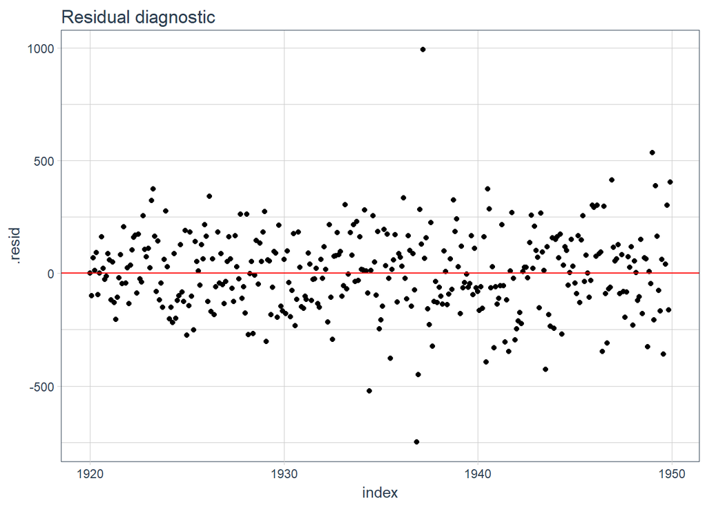

```r
sw_augment(fit_arima, timetk_idx = TRUE) %>%
    ggplot(aes(x = index, y = .resid)) +
    geom_point() +
    geom_hline(yintercept = 0, color = "red") +
    labs(title = "Residual diagnostic") +
    theme_tq()
```

### Step 3: Make a Forecast

Make a forecast using the `forecast()` function.

```r
# Forecast next 24 months
fcast_arima <- forecast(fit_arima, h = 24)
```

Use `sw_sweep()` to tidy the forecast output.

```r
# sw_sweep - tidies forecast output
fcast_tbl <- fcast_arima %>%
    sw_sweep(timetk_idx = TRUE)

fcast_tbl
```

```
## # A tibble: 384 x 7
##         index    key price lo.80 lo.95 hi.80 hi.95
##        <date>  <chr> <dbl> <dbl> <dbl> <dbl> <dbl>
##  1 1920-01-01 actual   895    NA    NA    NA    NA
##  2 1920-02-01 actual   780    NA    NA    NA    NA
##  3 1920-03-01 actual   894    NA    NA    NA    NA
##  4 1920-04-01 actual   867    NA    NA    NA    NA
##  5 1920-05-01 actual   975    NA    NA    NA    NA
##  6 1920-06-01 actual   834    NA    NA    NA    NA
##  7 1920-07-01 actual   886    NA    NA    NA    NA
##  8 1920-08-01 actual  1040    NA    NA    NA    NA
##  9 1920-09-01 actual  1009    NA    NA    NA    NA
## 10 1920-10-01 actual   991    NA    NA    NA    NA
## # ... with 374 more rows
```

Visualize the forecast.

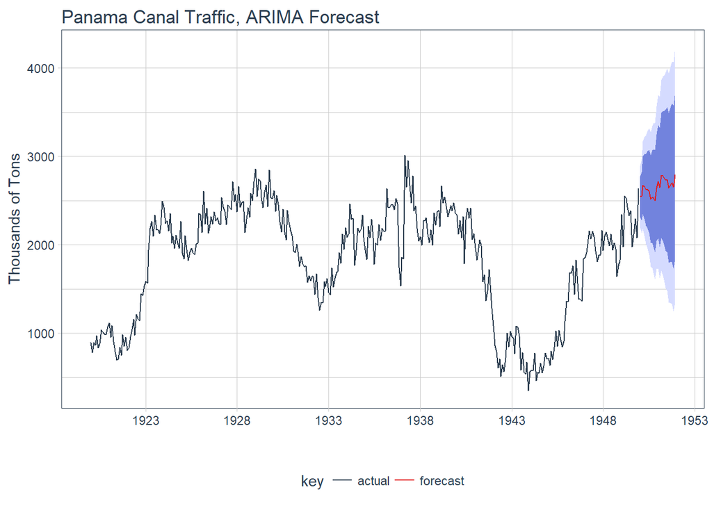

```r
# Visualize the forecast with ggplot
fcast_tbl %>%
    ggplot(aes(x = index, y = price, color = key)) +
    geom_ribbon(aes(ymin = lo.95, ymax = hi.95),
                fill = "#D5DBFF", color = NA, size = 0) +
    geom_ribbon(aes(ymin = lo.80, ymax = hi.80, fill = key),
                fill = "#596DD5", color = NA, size = 0, alpha = 0.8) +
    geom_line() +
    labs(title = "Panama Canal Traffic, ARIMA Forecast", x = "", y = "Thousands of Tons") +
    scale_x_date(date_breaks = "5 year", date_labels = "%Y") +
    scale_color_tq() +
    scale_fill_tq() +
    theme_tq()
```

# More Information

- Check out our [GitHub Page](https://github.com/business-science/sweep)
- Check out our [sweep vignettes](https://cran.r-project.org/web/packages/sweep/index.html)
- Check out our [Business Science Insights Blog](http://www.business-science.io/blog/index.html)